# Thesis Analysis

Nate Bender

11/19/2021

## Outline

This document serves two functions: as Nate’s detailed reference for steps and assumptions taken during analysis, and more broadly to communicate the analysis findings to advisors. Feel free to skip granular sections as needed.

The analysis seeks to answer my thesis research questions:

RQ1: Which explanatory variables from a variety of studies and theories are most strongly associated with climate activism, specifically the action of contacting elected officials?

RQ2: How might we define behaviorally oriented segments and which segments are specifically related to the climate change activism behavior “contacting elected officials”?

Table of contents:  
1) Varible renaming, cleanup, listwise deletion  
2) EDA & description of categorical variables levels reduction  
3) Factor analysis & composite variables creation  
4) OLR model  
5) Discussion of OLR results

## Variable renaming, cleanup, listwise deletion

## Factor Analysis

$$\\[.05in]$$
### Dynamic Norms *“Do you think that over the PAST/NEXT 12 months the percentage of adults in the United States who contacted elected officials to urge them to take action to reduce global warming is…”*

One factor solution:  
1. Two-item factor consisting of the two dynamic norms questions (changes in the number of ppl contacting reps in the past and future)

```
##
##  Spearman's rank correlation rho
##
## data:  d_accept$sr_24_past_contact and d_accept$sr_25_future_contact
## S = 54852767, p-value < 2.2e-16
## alternative hypothesis: true rho is not equal to 0
## sample estimates:
##      rho
## 0.711596
```

Correlation test of the two dynamic norms items shows moderate positive correlation, with Spearman’s rho of 0.711596 and p-value of 4.461691810^{-162}.

$$\\[.05in]$$

### Descriptive Norms

(contact) *“To what extent do you think that the following people ARE CONTACTING (writing letters, emailing, or calling) their elected representatives in Congress to urge action on reducing climate change?”*

(role models) *“How likely are you to consider each of these groups as behavioral role models?”*

Two factor solution (73% cumulative variance (hereafter: cv))  
1. All “contact” items 2. All “role model” items

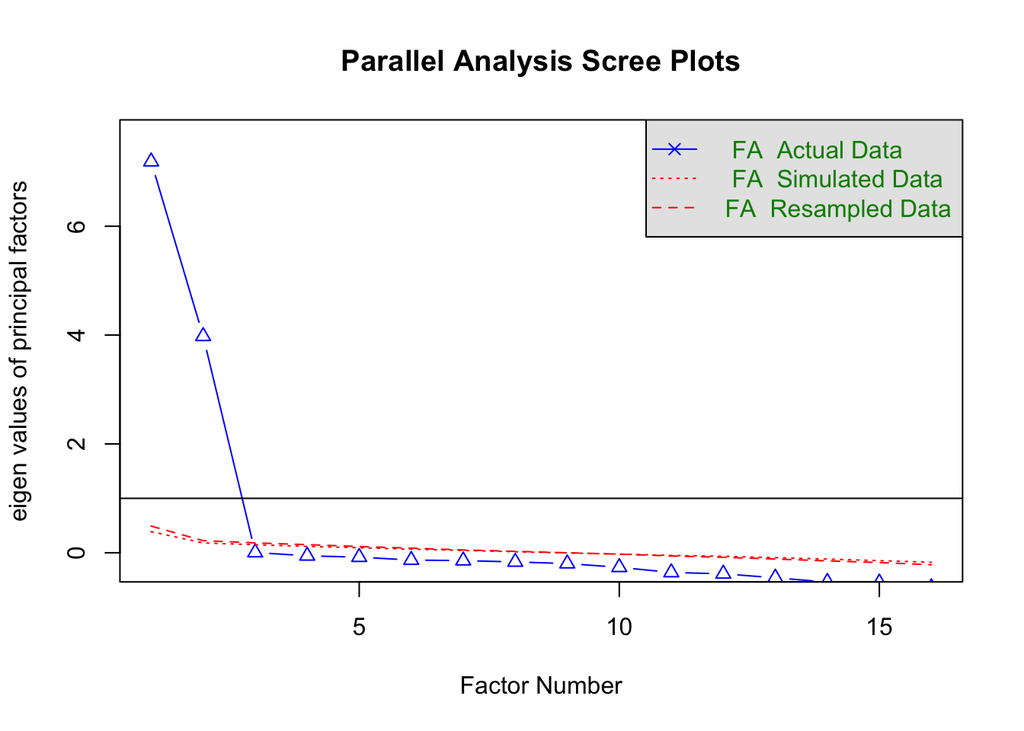

```
## Parallel analysis suggests that the number of factors =  2  and the number of components =  NA
```

```
## Factor Analysis using method =  minres
## Call: fa(r = d_pca_descriptivenorms, nfactors = 2, rotate = "Varimax",
##     fm = "minres")
## Standardized loadings (pattern matrix) based upon correlation matrix
##                                          MR1  MR2   h2   u2 com
## sr_19a_contacting_officials_parents     0.88 0.04 0.78 0.22 1.0
## sr_19b_contacting_officials_spouse      0.89 0.06 0.80 0.20 1.0
## sr_19c_contacting_officials_children    0.87 0.13 0.78 0.22 1.0
## sr_19d_contacting_officials_otherfamily 0.90 0.05 0.81 0.19 1.0
## sr_19e_contacting_officials_friends     0.90 0.12 0.82 0.18 1.0
## sr_19f_contacting_officials_coworkers   0.89 0.11 0.80 0.20 1.0
## sr_19g_contacting_officials_recpartners 0.92 0.11 0.86 0.14 1.0
## sr_19h_contacting_officials_faithcommun 0.91 0.17 0.85 0.15 1.1
## sr_20a_rolemodels_parents               0.07 0.71 0.50 0.50 1.0
## sr_20b_rolemodels_spouse                0.10 0.79 0.64 0.36 1.0
## sr_20c_rolemodels_children              0.04 0.81 0.65 0.35 1.0
## sr_20d_rolemodels_otherfamily           0.20 0.82 0.71 0.29 1.1
## sr_20e_rolemodels_friends               0.20 0.85 0.77 0.23 1.1
## sr_20f_rolemodels_coworkers             0.06 0.78 0.62 0.38 1.0
## sr_20g_rolemodels_recpartners           0.13 0.85 0.73 0.27 1.0
## sr_20h_rolemodels_faithcommun           0.06 0.79 0.62 0.38 1.0
##
##                        MR1  MR2
## SS loadings           6.52 5.22
## Proportion Var        0.41 0.33
## Cumulative Var        0.41 0.73
## Proportion Explained  0.56 0.44
## Cumulative Proportion 0.56 1.00
##
## Mean item complexity =  1
## Test of the hypothesis that 2 factors are sufficient.
##
## The degrees of freedom for the null model are  120  and the objective function was  17.55 with Chi Square of  18299.58
## The degrees of freedom for the model are 89  and the objective function was  1.74
##
## The root mean square of the residuals (RMSR) is  0.03
## The df corrected root mean square of the residuals is  0.04
##
## The harmonic number of observations is  710 with the empirical chi square  196.91  with prob <  3.9e-10
## The total number of observations was  1050  with Likelihood Chi Square =  1808.51  with prob <  2.000002e-318
##
## Tucker Lewis Index of factoring reliability =  0.872
## RMSEA index =  0.136  and the 90 % confidence intervals are  0.13 0.141
## BIC =  1189.38
## Fit based upon off diagonal values = 1
## Measures of factor score adequacy
##                                                    MR1  MR2
## Correlation of (regression) scores with factors   0.99 0.97
## Multiple R square of scores with factors          0.97 0.94
## Minimum correlation of possible factor scores     0.94 0.88
```

```
##
## Loadings:
##                                         MR1   MR2
## sr_19a_contacting_officials_parents     0.885
## sr_19b_contacting_officials_spouse      0.891
## sr_19c_contacting_officials_children    0.871
## sr_19d_contacting_officials_otherfamily 0.900
## sr_19e_contacting_officials_friends     0.897
## sr_19f_contacting_officials_coworkers   0.887
## sr_19g_contacting_officials_recpartners 0.919
## sr_19h_contacting_officials_faithcommun 0.907
## sr_20a_rolemodels_parents                     0.705
## sr_20b_rolemodels_spouse                      0.794
## sr_20c_rolemodels_children                    0.806
## sr_20d_rolemodels_otherfamily                 0.819
## sr_20e_rolemodels_friends                     0.853
## sr_20f_rolemodels_coworkers                   0.785
## sr_20g_rolemodels_recpartners                 0.845
## sr_20h_rolemodels_faithcommun                 0.786
##
##                  MR1   MR2
## SS loadings    6.521 5.217
## Proportion Var 0.408 0.326
## Cumulative Var 0.408 0.734
```

$$\\[.05in]$$
#### Descriptive Norms (role models) - 2nd factor (All) - Cronbach Alpha

```
##
## Reliability analysis
## Call: psych::alpha(x = d_pca_descriptivecontactnorms_all, use = "pairwise")
##
##   raw_alpha std.alpha G6(smc) average_r S/N    ase mean  sd median_r
##       0.94      0.94    0.95      0.67  16 0.0029  3.6 1.4     0.65
##
##  lower alpha upper     95% confidence boundaries
## 0.93 0.94 0.95
##
##  Reliability if an item is dropped:
##                               raw_alpha std.alpha G6(smc) average_r S/N
## sr_20a_rolemodels_parents          0.94      0.94    0.94      0.69  16
## sr_20b_rolemodels_spouse           0.93      0.93    0.93      0.67  14
## sr_20c_rolemodels_children         0.93      0.93    0.93      0.67  14
## sr_20d_rolemodels_otherfamily      0.93      0.93    0.94      0.66  14
## sr_20e_rolemodels_friends          0.93      0.93    0.93      0.65  13
## sr_20f_rolemodels_coworkers        0.93      0.94    0.94      0.67  15
## sr_20g_rolemodels_recpartners      0.93      0.93    0.94      0.66  13
## sr_20h_rolemodels_faithcommun      0.93      0.94    0.94      0.67  14
##                               alpha se  var.r med.r
## sr_20a_rolemodels_parents       0.0030 0.0050  0.67
## sr_20b_rolemodels_spouse        0.0033 0.0056  0.65
## sr_20c_rolemodels_children      0.0033 0.0052  0.65
## sr_20d_rolemodels_otherfamily   0.0033 0.0056  0.66
## sr_20e_rolemodels_friends       0.0034 0.0042  0.64
## sr_20f_rolemodels_coworkers     0.0032 0.0065  0.65
## sr_20g_rolemodels_recpartners   0.0034 0.0051  0.65
## sr_20h_rolemodels_faithcommun   0.0032 0.0064  0.65
##
##  Item statistics
##                                 n raw.r std.r r.cor r.drop mean  sd
## sr_20a_rolemodels_parents     807  0.76  0.78  0.73   0.71  3.7 1.8
## sr_20b_rolemodels_spouse      844  0.83  0.85  0.83   0.80  3.8 1.7
## sr_20c_rolemodels_children    921  0.84  0.84  0.82   0.79  3.9 1.8
## sr_20d_rolemodels_otherfamily 929  0.84  0.86  0.85   0.81  3.3 1.6
## sr_20e_rolemodels_friends     916  0.86  0.89  0.88   0.85  3.3 1.5
## sr_20f_rolemodels_coworkers   970  0.82  0.82  0.79   0.76  3.6 1.8
## sr_20g_rolemodels_recpartners 943  0.86  0.88  0.86   0.83  3.4 1.6
## sr_20h_rolemodels_faithcommun 911  0.82  0.83  0.79   0.77  3.8 1.8
##
## Non missing response frequency for each item
##                                  1    2    3    4    6 miss
## sr_20a_rolemodels_parents     0.20 0.05 0.21 0.22 0.31 0.23
## sr_20b_rolemodels_spouse      0.16 0.05 0.22 0.27 0.30 0.20
## sr_20c_rolemodels_children    0.15 0.06 0.21 0.22 0.36 0.12
## sr_20d_rolemodels_otherfamily 0.18 0.07 0.33 0.25 0.16 0.12
## sr_20e_rolemodels_friends     0.17 0.07 0.33 0.29 0.13 0.13
## sr_20f_rolemodels_coworkers   0.17 0.08 0.29 0.17 0.28 0.08
## sr_20g_rolemodels_recpartners 0.18 0.08 0.35 0.19 0.21 0.10
## sr_20h_rolemodels_faithcommun 0.17 0.06 0.26 0.17 0.34 0.13
```

Alpha of .94 shows strong reliability, with no significant improvement found by dropping any items.

$$\\[.05in]$$
### Injunctive Norms (contact) *“To what extent do you think that the following people EXPECT YOU to contact (writing letters, emailing, or calling) your elected representatives to urge action on reducing climate change?”*

(motivation) *“How motivated are you to comply with the expectations of each of these people?”*

Scree plot suggests two factors (76% cv). 1. All “contact” items 2. All “motivation” items

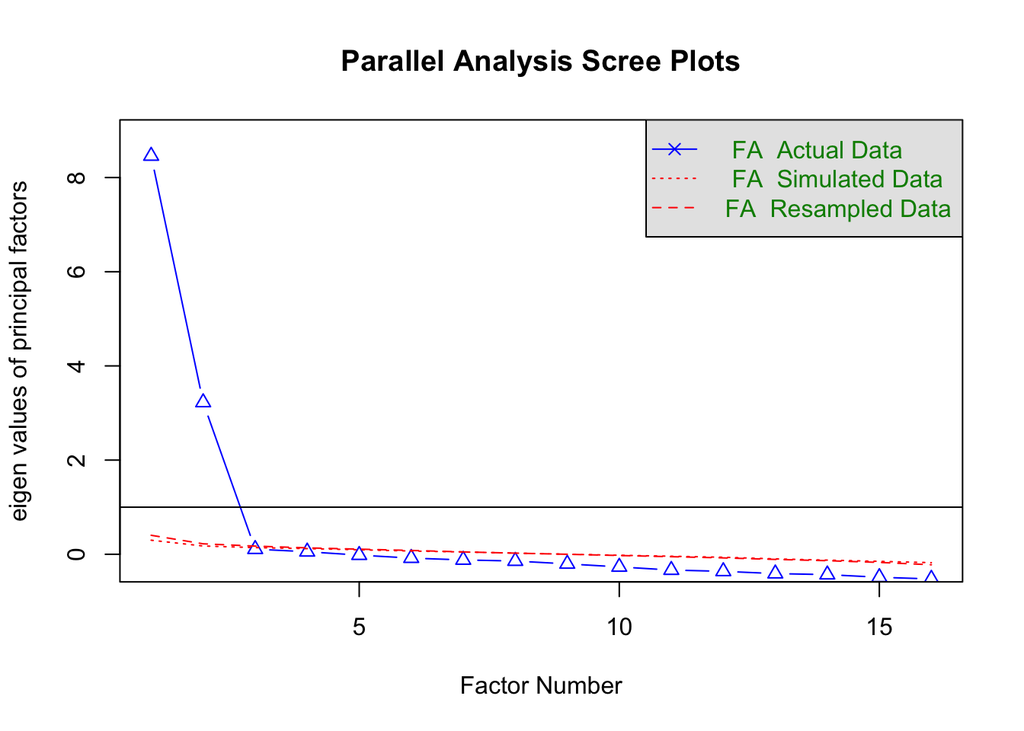

```
## Parallel analysis suggests that the number of factors =  2  and the number of components =  NA
```

```
## Factor Analysis using method =  minres
## Call: fa(r = d_pca_injunctivecontactnorms, nfactors = 2, rotate = "Varimax",
##     fm = "minres")
## Standardized loadings (pattern matrix) based upon correlation matrix
##                                         MR1  MR2   h2    u2 com
## sr_22a_expect_contact_parents          0.90 0.16 0.83 0.172 1.1
## sr_22b_expect_contact_spouse           0.91 0.15 0.85 0.151 1.1
## sr_22c_expect_contact_children         0.86 0.24 0.80 0.199 1.2
## sr_22d_expect_contact_otherfamily      0.92 0.12 0.86 0.138 1.0
## sr_22e_expect_contact_friends          0.95 0.10 0.91 0.087 1.0
## sr_22f_expect_contact_coworkers        0.91 0.19 0.86 0.137 1.1
## sr_22g_expect_contact_recpartners      0.93 0.16 0.89 0.109 1.1
## sr_22h_expect_contact_faithcommun      0.90 0.24 0.87 0.132 1.1
## sr_23a_motivated_to_comply_parents     0.10 0.70 0.50 0.504 1.0
## sr_23b_motivated_to_comply_spouse      0.12 0.78 0.62 0.383 1.0
## sr_23c_motivated_to_comply_children    0.10 0.77 0.60 0.402 1.0
## sr_23d_motivated_to_comply_otherfamily 0.31 0.83 0.78 0.220 1.3
## sr_23e_motivated_to_comply_friends     0.33 0.82 0.77 0.228 1.3
## sr_23f_motivated_to_comply_coworkers   0.14 0.80 0.65 0.347 1.1
## sr_23g_motivated_to_comply_recpartners 0.26 0.83 0.76 0.242 1.2
## sr_23h_motivated_to_comply_faithcommun 0.14 0.76 0.60 0.401 1.1
##
##                        MR1  MR2
## SS loadings           6.97 5.18
## Proportion Var        0.44 0.32
## Cumulative Var        0.44 0.76
## Proportion Explained  0.57 0.43
## Cumulative Proportion 0.57 1.00
##
## Mean item complexity =  1.1
## Test of the hypothesis that 2 factors are sufficient.
##
## The degrees of freedom for the null model are  120  and the objective function was  22.9 with Chi Square of  23882.02
## The degrees of freedom for the model are 89  and the objective function was  4.73
##
## The root mean square of the residuals (RMSR) is  0.04
## The df corrected root mean square of the residuals is  0.05
##
## The harmonic number of observations is  784 with the empirical chi square  342.78  with prob <  1.9e-31
## The total number of observations was  1050  with Likelihood Chi Square =  4929.58  with prob <  0
##
## Tucker Lewis Index of factoring reliability =  0.725
## RMSEA index =  0.228  and the 90 % confidence intervals are  0.222 0.233
## BIC =  4310.45
## Fit based upon off diagonal values = 0.99
## Measures of factor score adequacy
##                                                    MR1  MR2
## Correlation of (regression) scores with factors   0.99 0.97
## Multiple R square of scores with factors          0.98 0.94
## Minimum correlation of possible factor scores     0.96 0.88
```

```
##
## Loadings:
##                                        MR1   MR2
## sr_22a_expect_contact_parents          0.896
## sr_22b_expect_contact_spouse           0.909
## sr_22c_expect_contact_children         0.863
## sr_22d_expect_contact_otherfamily      0.921
## sr_22e_expect_contact_friends          0.950
## sr_22f_expect_contact_coworkers        0.909
## sr_22g_expect_contact_recpartners      0.931
## sr_22h_expect_contact_faithcommun      0.901
## sr_23a_motivated_to_comply_parents           0.696
## sr_23b_motivated_to_comply_spouse            0.777
## sr_23c_motivated_to_comply_children          0.768
## sr_23d_motivated_to_comply_otherfamily 0.312 0.826
## sr_23e_motivated_to_comply_friends     0.327 0.815
## sr_23f_motivated_to_comply_coworkers         0.796
## sr_23g_motivated_to_comply_recpartners       0.832
## sr_23h_motivated_to_comply_faithcommun       0.761
##
##                  MR1   MR2
## SS loadings    6.971 5.178
## Proportion Var 0.436 0.324
## Cumulative Var 0.436 0.759
```

#### Injunctive Norms (contact) - 1st factor (All) - Cronbach Alpha

```
##
## Reliability analysis
## Call: psych::alpha(x = d_pca_injunctivenorms_all, use = "pairwise")
##
##   raw_alpha std.alpha G6(smc) average_r S/N     ase mean sd median_r
##       0.98      0.98    0.98      0.87  54 0.00085  1.9  1     0.87
##
##  lower alpha upper     95% confidence boundaries
## 0.98 0.98 0.98
##
##  Reliability if an item is dropped:
##                                   raw_alpha std.alpha G6(smc) average_r S/N
## sr_22a_expect_contact_parents          0.98      0.98    0.98      0.87  47
## sr_22b_expect_contact_spouse           0.98      0.98    0.98      0.87  48
## sr_22c_expect_contact_children         0.98      0.98    0.98      0.88  51
## sr_22d_expect_contact_otherfamily      0.98      0.98    0.98      0.87  49
## sr_22e_expect_contact_friends          0.98      0.98    0.98      0.87  46
## sr_22f_expect_contact_coworkers        0.98      0.98    0.98      0.87  48
## sr_22g_expect_contact_recpartners      0.98      0.98    0.98      0.87  46
## sr_22h_expect_contact_faithcommun      0.98      0.98    0.98      0.87  47
##                                   alpha se   var.r med.r
## sr_22a_expect_contact_parents      0.00099 0.00038  0.87
## sr_22b_expect_contact_spouse       0.00097 0.00041  0.87
## sr_22c_expect_contact_children     0.00091 0.00020  0.88
## sr_22d_expect_contact_otherfamily  0.00096 0.00044  0.88
## sr_22e_expect_contact_friends      0.00101 0.00045  0.87
## sr_22f_expect_contact_coworkers    0.00098 0.00048  0.87
## sr_22g_expect_contact_recpartners  0.00100 0.00044  0.87
## sr_22h_expect_contact_faithcommun  0.00100 0.00035  0.87
##
##  Item statistics
##                                     n raw.r std.r r.cor r.drop mean  sd
## sr_22a_expect_contact_parents     704  0.92  0.95  0.94   0.93  1.9 1.1
## sr_22b_expect_contact_spouse      749  0.94  0.94  0.93   0.92  1.9 1.1
## sr_22c_expect_contact_children    690  0.91  0.92  0.90   0.89  2.0 1.1
## sr_22d_expect_contact_otherfamily 847  0.94  0.94  0.93   0.92  1.9 1.1
## sr_22e_expect_contact_friends     850  0.95  0.95  0.95   0.94  1.9 1.1
## sr_22f_expect_contact_coworkers   741  0.94  0.94  0.93   0.92  1.9 1.1
## sr_22g_expect_contact_recpartners 813  0.95  0.95  0.95   0.94  1.9 1.0
## sr_22h_expect_contact_faithcommun 685  0.94  0.95  0.94   0.93  2.0 1.1
##
## Non missing response frequency for each item
##                                      1    2    3    4 miss
## sr_22a_expect_contact_parents     0.56 0.11 0.22 0.12 0.33
## sr_22b_expect_contact_spouse      0.53 0.13 0.21 0.12 0.29
## sr_22c_expect_contact_children    0.50 0.14 0.26 0.11 0.34
## sr_22d_expect_contact_otherfamily 0.54 0.15 0.21 0.10 0.19
## sr_22e_expect_contact_friends     0.53 0.17 0.20 0.10 0.19
## sr_22f_expect_contact_coworkers   0.53 0.16 0.21 0.10 0.29
## sr_22g_expect_contact_recpartners 0.53 0.17 0.21 0.09 0.23
## sr_22h_expect_contact_faithcommun 0.52 0.13 0.23 0.12 0.35
```

$$\\[.05in]$$

#### Injunctive Norms (motivation) - 2nd factor (all) - Cronbach Alpha

```
##
## Reliability analysis
## Call: psych::alpha(x = d_pca_injunctivemotivation_all, use = "pairwise")
##
##   raw_alpha std.alpha G6(smc) average_r S/N    ase mean sd median_r
##       0.94      0.94    0.94      0.65  15 0.0031  4.7  2     0.63
##
##  lower alpha upper     95% confidence boundaries
## 0.93 0.94 0.94
##
##  Reliability if an item is dropped:
##                                        raw_alpha std.alpha G6(smc) average_r
## sr_23a_motivated_to_comply_parents          0.93      0.93    0.93      0.67
## sr_23b_motivated_to_comply_spouse           0.93      0.93    0.93      0.65
## sr_23c_motivated_to_comply_children         0.93      0.93    0.93      0.66
## sr_23d_motivated_to_comply_otherfamily      0.92      0.92    0.92      0.63
## sr_23e_motivated_to_comply_friends          0.92      0.92    0.92      0.63
## sr_23f_motivated_to_comply_coworkers        0.93      0.93    0.93      0.65
## sr_23g_motivated_to_comply_recpartners      0.92      0.92    0.92      0.63
## sr_23h_motivated_to_comply_faithcommun      0.93      0.93    0.93      0.66
##                                        S/N alpha se  var.r med.r
## sr_23a_motivated_to_comply_parents      14   0.0032 0.0058  0.64
## sr_23b_motivated_to_comply_spouse       13   0.0035 0.0079  0.63
## sr_23c_motivated_to_comply_children     13   0.0034 0.0074  0.64
## sr_23d_motivated_to_comply_otherfamily  12   0.0037 0.0051  0.62
## sr_23e_motivated_to_comply_friends      12   0.0037 0.0045  0.62
## sr_23f_motivated_to_comply_coworkers    13   0.0035 0.0073  0.63
## sr_23g_motivated_to_comply_recpartners  12   0.0037 0.0049  0.63
## sr_23h_motivated_to_comply_faithcommun  13   0.0034 0.0074  0.62
##
##  Item statistics
##                                           n raw.r std.r r.cor r.drop mean  sd
## sr_23a_motivated_to_comply_parents     1050  0.76  0.76  0.70   0.68  5.0 2.5
## sr_23b_motivated_to_comply_spouse      1046  0.82  0.82  0.79   0.76  5.0 2.4
## sr_23c_motivated_to_comply_children    1047  0.81  0.80  0.77   0.74  5.1 2.5
## sr_23d_motivated_to_comply_otherfamily 1049  0.88  0.88  0.88   0.84  4.3 2.3
## sr_23e_motivated_to_comply_friends     1050  0.87  0.88  0.87   0.83  4.3 2.2
## sr_23f_motivated_to_comply_coworkers   1050  0.83  0.83  0.80   0.78  4.7 2.5
## sr_23g_motivated_to_comply_recpartners 1042  0.87  0.88  0.87   0.83  4.5 2.4
## sr_23h_motivated_to_comply_faithcommun 1039  0.81  0.81  0.77   0.74  5.0 2.6
##
## Non missing response frequency for each item
##                                           1    3    4    7    8 miss
## sr_23a_motivated_to_comply_parents     0.17 0.05 0.37 0.11 0.30 0.00
## sr_23b_motivated_to_comply_spouse      0.15 0.05 0.40 0.13 0.27 0.00
## sr_23c_motivated_to_comply_children    0.15 0.05 0.38 0.10 0.32 0.00
## sr_23d_motivated_to_comply_otherfamily 0.19 0.08 0.48 0.08 0.17 0.00
## sr_23e_motivated_to_comply_friends     0.18 0.07 0.50 0.09 0.16 0.00
## sr_23f_motivated_to_comply_coworkers   0.18 0.07 0.41 0.06 0.28 0.00
## sr_23g_motivated_to_comply_recpartners 0.18 0.08 0.45 0.09 0.21 0.01
## sr_23h_motivated_to_comply_faithcommun 0.17 0.05 0.37 0.09 0.32 0.01
```

.94 alpha shows strong reliabiity; no increase with dropping any items.

$$\\[.05in]$$
### CIM - Benefits *“How often do you hear ____ talk about the importance of reducing climate change?”*
*[your friends, family, and coworkers]*
*[public figures whom you respect]*
*[about the importance of reducing climate change in the media? (TV, movies, radio, newspapers/news websites, magazines, etc.)]*

One-factor solution (58% cv):  
1. Multi-item composite variable: F/Fam/Cowork, Public Figures, Media

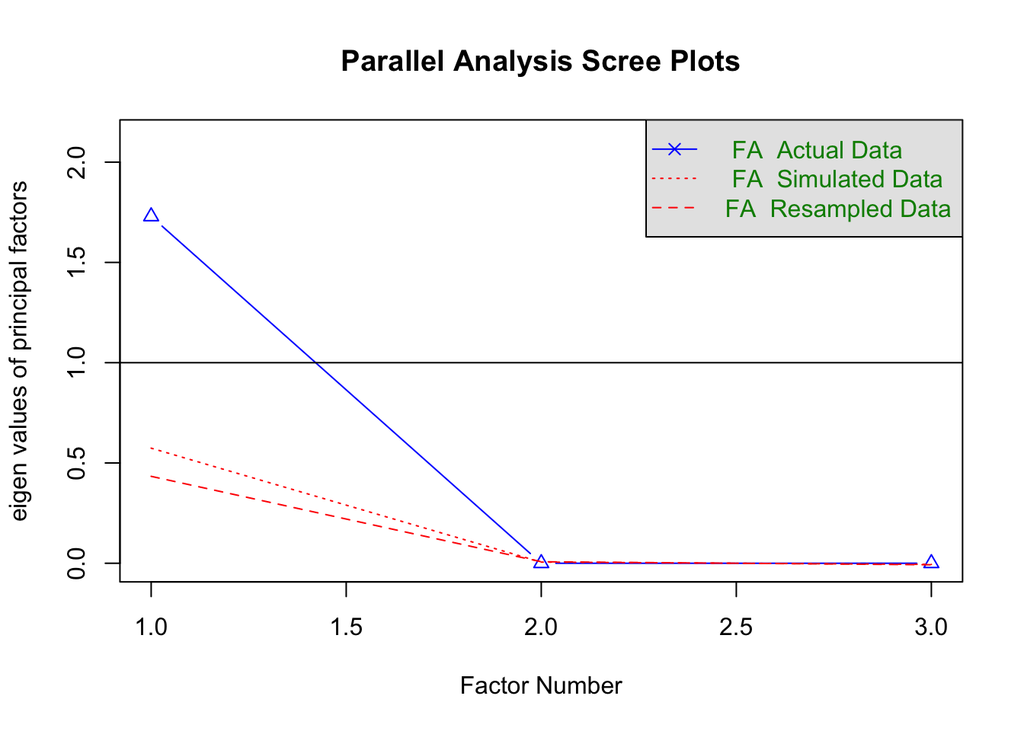

```
## Parallel analysis suggests that the number of factors =  1  and the number of components =  NA
```

```
## Factor Analysis using method =  minres
## Call: fa(r = d_pca_CIMbenefits, nfactors = 1, rotate = "Varimax", fm = "minres")
## Standardized loadings (pattern matrix) based upon correlation matrix
##                              MR1   h2   u2 com
## sr_16_hear_friends_talk     0.64 0.41 0.59   1
## sr_17_hear_media            0.74 0.54 0.46   1
## sr_18_hear_public_officials 0.88 0.78 0.22   1
##
##                 MR1
## SS loadings    1.73
## Proportion Var 0.58
##
## Mean item complexity =  1
## Test of the hypothesis that 1 factor is sufficient.
##
## The degrees of freedom for the null model are  3  and the objective function was  0.96 with Chi Square of  1004.89
## The degrees of freedom for the model are 0  and the objective function was  0
##
## The root mean square of the residuals (RMSR) is  0
## The df corrected root mean square of the residuals is  NA
##
## The harmonic number of observations is  1044 with the empirical chi square  0  with prob <  NA
## The total number of observations was  1050  with Likelihood Chi Square =  0  with prob <  NA
##
## Tucker Lewis Index of factoring reliability =  -Inf
## Fit based upon off diagonal values = 1
## Measures of factor score adequacy
##                                                    MR1
## Correlation of (regression) scores with factors   0.92
## Multiple R square of scores with factors          0.84
## Minimum correlation of possible factor scores     0.69
```

```
##
## Loadings:
##                             MR1
## sr_16_hear_friends_talk     0.637
## sr_17_hear_media            0.737
## sr_18_hear_public_officials 0.884
##
##                  MR1
## SS loadings    1.729
## Proportion Var 0.576
```

#### CIM - Benefits - Cronbach Alpha

```
##
## Reliability analysis
## Call: psych::alpha(x = d_pca_CIMbenefits, use = "pairwise")
##
##   raw_alpha std.alpha G6(smc) average_r S/N   ase mean  sd median_r
##       0.79      0.79    0.73      0.56 3.8 0.011  2.4 1.1     0.56
##
##  lower alpha upper     95% confidence boundaries
## 0.77 0.79 0.81
##
##  Reliability if an item is dropped:
##                             raw_alpha std.alpha G6(smc) average_r S/N alpha se
## sr_16_hear_friends_talk          0.79      0.79    0.65      0.65 3.7    0.013
## sr_17_hear_media                 0.72      0.72    0.56      0.56 2.6    0.017
## sr_18_hear_public_officials      0.63      0.64    0.47      0.47 1.8    0.022
##                             var.r med.r
## sr_16_hear_friends_talk        NA  0.65
## sr_17_hear_media               NA  0.56
## sr_18_hear_public_officials    NA  0.47
##
##  Item statistics
##                                n raw.r std.r r.cor r.drop mean  sd
## sr_16_hear_friends_talk     1047  0.79  0.81  0.63   0.57  2.0 1.2
## sr_17_hear_media            1046  0.86  0.84  0.72   0.64  2.8 1.4
## sr_18_hear_public_officials 1045  0.88  0.88  0.80   0.71  2.3 1.3
##
## Non missing response frequency for each item
##                                1    2    3    4    5 miss
## sr_16_hear_friends_talk     0.47 0.26 0.13 0.09 0.04    0
## sr_17_hear_media            0.22 0.24 0.18 0.20 0.15    0
## sr_18_hear_public_officials 0.33 0.28 0.16 0.16 0.06    0
```

.79 alpha indicates good reliability; no increase with dropping any of the three items.

$$\\[.05in]$$
### CIM - Perceived Risk *“How important is each of the following issues to you today?”*
*“How important is the issue of climate change to you personally?”*
*“How worried are you about climate change?”*
*“How much do you think climate change will harm you personally?”*
*“How much do you think climate change will harm future generations of people?”*

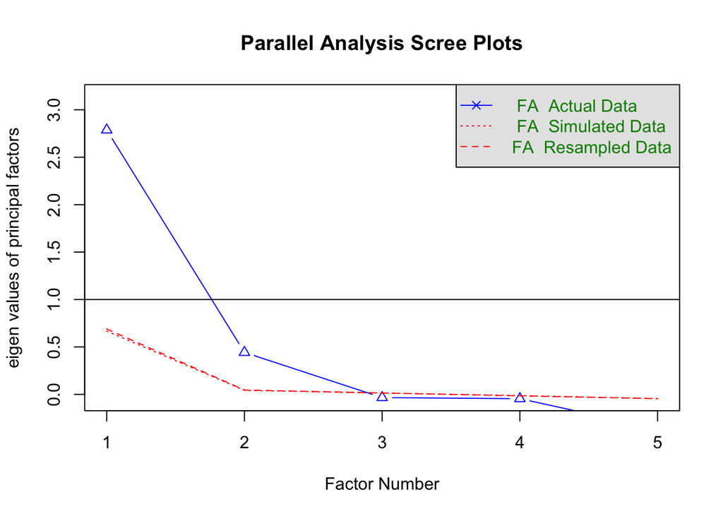

```
## Parallel analysis suggests that the number of factors =  2  and the number of components =  NA
```

```
## Factor Analysis using method =  minres
## Call: fa(r = d_pca_CIMperceivedrisk, nfactors = 2, rotate = "Varimax",
##     fm = "minres")
## Standardized loadings (pattern matrix) based upon correlation matrix
##                                          MR1  MR2   h2     u2 com
## sr_3b_importance_climatechange_reversed 0.84 0.17 0.73 0.2714 1.1
## sr_8_importance_personally_reversed     0.91 0.22 0.88 0.1209 1.1
## sr_9_worried_reversed                   0.86 0.21 0.79 0.2142 1.1
## sr_10_harm_you_personally_reversed      0.18 0.98 1.00 0.0045 1.1
## sr_11_harm_future_generations_reversed  0.31 0.57 0.42 0.5757 1.5
##
##                        MR1  MR2
## SS loadings           2.40 1.41
## Proportion Var        0.48 0.28
## Cumulative Var        0.48 0.76
## Proportion Explained  0.63 0.37
## Cumulative Proportion 0.63 1.00
##
## Mean item complexity =  1.2
## Test of the hypothesis that 2 factors are sufficient.
##
## The degrees of freedom for the null model are  10  and the objective function was  3 with Chi Square of  3144.05
## The degrees of freedom for the model are 1  and the objective function was  0.01
##
## The root mean square of the residuals (RMSR) is  0.01
## The df corrected root mean square of the residuals is  0.03
##
## The harmonic number of observations is  1041 with the empirical chi square  1.51  with prob <  0.22
## The total number of observations was  1050  with Likelihood Chi Square =  10.73  with prob <  0.0011
##
## Tucker Lewis Index of factoring reliability =  0.969
## RMSEA index =  0.096  and the 90 % confidence intervals are  0.05 0.152
## BIC =  3.78
## Fit based upon off diagonal values = 1
## Measures of factor score adequacy
##                                                    MR1  MR2
## Correlation of (regression) scores with factors   0.96 1.00
## Multiple R square of scores with factors          0.92 0.99
## Minimum correlation of possible factor scores     0.85 0.99
```

```
##
## Loadings:
##                                         MR1   MR2
## sr_3b_importance_climatechange_reversed 0.836
## sr_8_importance_personally_reversed     0.911
## sr_9_worried_reversed                   0.861
## sr_10_harm_you_personally_reversed            0.981
## sr_11_harm_future_generations_reversed  0.312 0.572
##
##                 MR1   MR2
## SS loadings    2.40 1.414
## Proportion Var 0.48 0.283
## Cumulative Var 0.48 0.763
```

#### CIM - Perceived Risk - 1st factor (Personal) - Cronbach Alpha

```
##
## Reliability analysis
## Call: psych::alpha(x = d_pca_CIMperceivedrisk_importance_worry, use = "pairwise")
##
##   raw_alpha std.alpha G6(smc) average_r S/N    ase mean  sd median_r
##       0.91      0.92    0.89       0.8  12 0.0044  3.2 1.1      0.8
##
##  lower alpha upper     95% confidence boundaries
## 0.9 0.91 0.92
##
##  Reliability if an item is dropped:
##                                         raw_alpha std.alpha G6(smc) average_r
## sr_3b_importance_climatechange_reversed      0.89      0.91    0.83      0.83
## sr_8_importance_personally_reversed          0.83      0.86    0.75      0.75
## sr_9_worried_reversed                        0.89      0.89    0.80      0.80
##                                          S/N alpha se var.r med.r
## sr_3b_importance_climatechange_reversed 10.1   0.0059    NA  0.83
## sr_8_importance_personally_reversed      6.1   0.0092    NA  0.75
## sr_9_worried_reversed                    8.0   0.0069    NA  0.80
##
##  Item statistics
##                                            n raw.r std.r r.cor r.drop mean   sd
## sr_3b_importance_climatechange_reversed 1046  0.93  0.92  0.84   0.81  3.5 1.37
## sr_8_importance_personally_reversed     1048  0.95  0.95  0.91   0.87  3.3 1.26
## sr_9_worried_reversed                   1042  0.91  0.93  0.88   0.83  2.9 0.98
##
## Non missing response frequency for each item
##                                            1    2    3    4    5 miss
## sr_3b_importance_climatechange_reversed 0.13 0.10 0.23 0.22 0.31 0.00
## sr_8_importance_personally_reversed     0.11 0.14 0.30 0.23 0.22 0.00
## sr_9_worried_reversed                   0.13 0.18 0.40 0.30 0.00 0.01
```

.91 alpha shows strong reliability; decreases when any items are dropped.

$$\\[.05in]$$
### Efficacy *“Below is a list of actions that individuals could take to reduce climate change. If YOU took these actions, how effective would each be for reducing climate change?”*
*“Below are some public and private organizations who make decisions that have an impact on climate change. In general, how COMPETENT is each in addressing climate change?”*
*“In general, how RESPONSIVE is each in addressing climate change?”*
*“How much do you agree that each type of organization is generally IN A POSITION TO EFFECTIVELY reduce climate change?”*

1. 1-item variable: 21a: Is contacting elected reps an effective action?

Two-factor solution (61% cv):  
1. Multi-item composite variable: All types (fed, state, business, ngo) are in a position to effect change  
2. Multi-item composite variable: All types’ (fed, state, business, ngo) competency and responsiveness

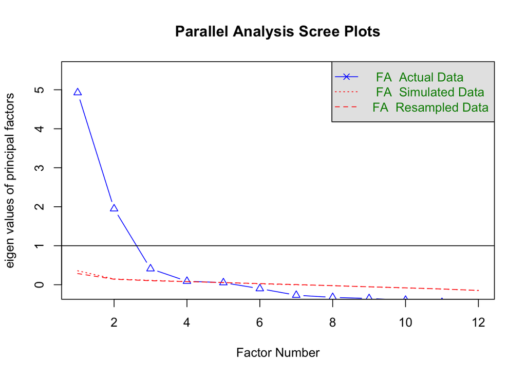

```
## Parallel analysis suggests that the number of factors =  3  and the number of components =  NA
```

```
## Factor Analysis using method =  minres
## Call: fa(r = d_pca_efficacygroup, nfactors = 2, rotate = "Varimax",
##     fm = "minres")
## Standardized loadings (pattern matrix) based upon correlation matrix
##                              MR1  MR2   h2   u2 com
## sr_27a_competent_fed       -0.04 0.76 0.59 0.41 1.0
## sr_27b_competent_state      0.29 0.67 0.54 0.46 1.4
## sr_27c_competent_business   0.26 0.71 0.58 0.42 1.3
## sr_27d_competent_ngo        0.55 0.44 0.49 0.51 1.9
## sr_28a_responsive_fed      -0.09 0.76 0.59 0.41 1.0
## sr_28b_responsive_state     0.23 0.73 0.59 0.41 1.2
## sr_28c_responsive_business  0.26 0.72 0.59 0.41 1.2
## sr_28d_responsive_ngo       0.48 0.46 0.44 0.56 2.0
## sr_29a_effective_fed        0.80 0.10 0.65 0.35 1.0
## sr_29b_effective_state      0.89 0.11 0.81 0.19 1.0
## sr_29c_effective_business   0.88 0.08 0.79 0.21 1.0
## sr_29d_effective_ngo        0.83 0.11 0.71 0.29 1.0
##
##                        MR1  MR2
## SS loadings           3.72 3.63
## Proportion Var        0.31 0.30
## Cumulative Var        0.31 0.61
## Proportion Explained  0.51 0.49
## Cumulative Proportion 0.51 1.00
##
## Mean item complexity =  1.3
## Test of the hypothesis that 2 factors are sufficient.
##
## The degrees of freedom for the null model are  66  and the objective function was  9.14 with Chi Square of  9539.62
## The degrees of freedom for the model are 43  and the objective function was  2.01
##
## The root mean square of the residuals (RMSR) is  0.07
## The df corrected root mean square of the residuals is  0.09
##
## The harmonic number of observations is  1044 with the empirical chi square  680.74  with prob <  1.2e-115
## The total number of observations was  1050  with Likelihood Chi Square =  2097.43  with prob <  0
##
## Tucker Lewis Index of factoring reliability =  0.667
## RMSEA index =  0.213  and the 90 % confidence intervals are  0.206 0.221
## BIC =  1798.3
## Fit based upon off diagonal values = 0.98
## Measures of factor score adequacy
##                                                    MR1  MR2
## Correlation of (regression) scores with factors   0.96 0.94
## Multiple R square of scores with factors          0.93 0.88
## Minimum correlation of possible factor scores     0.85 0.77
```

```
##
## Loadings:
##                            MR1    MR2
## sr_27a_competent_fed               0.765
## sr_27b_competent_state             0.673
## sr_27c_competent_business          0.713
## sr_27d_competent_ngo        0.546  0.437
## sr_28a_responsive_fed              0.762
## sr_28b_responsive_state            0.734
## sr_28c_responsive_business         0.725
## sr_28d_responsive_ngo       0.482  0.456
## sr_29a_effective_fed        0.798
## sr_29b_effective_state      0.894
## sr_29c_effective_business   0.885
## sr_29d_effective_ngo        0.835
##
##                  MR1   MR2
## SS loadings    3.724 3.630
## Proportion Var 0.310 0.302
## Cumulative Var 0.310 0.613
```

#### Efficacy - 1st Factor (All types’ ability to effect change) - Cronbach Alpha

```
##
## Reliability analysis
## Call: psych::alpha(x = d_pca_efficacyeffectchange_all, use = "pairwise")
##
##   raw_alpha std.alpha G6(smc) average_r S/N    ase mean  sd median_r
##       0.93      0.93    0.92      0.76  13 0.0038  3.4 1.1     0.76
##
##  lower alpha upper     95% confidence boundaries
## 0.92 0.93 0.93
##
##  Reliability if an item is dropped:
##                           raw_alpha std.alpha G6(smc) average_r  S/N alpha se
## sr_29a_effective_fed           0.91      0.91    0.87      0.77 10.1   0.0048
## sr_29b_effective_state         0.89      0.89    0.85      0.73  7.9   0.0062
## sr_29c_effective_business      0.90      0.90    0.87      0.75  8.9   0.0055
## sr_29d_effective_ngo           0.92      0.92    0.89      0.79 11.6   0.0043
##                             var.r med.r
## sr_29a_effective_fed      0.00054  0.78
## sr_29b_effective_state    0.00401  0.75
## sr_29c_effective_business 0.00902  0.75
## sr_29d_effective_ngo      0.00238  0.79
##
##  Item statistics
##                              n raw.r std.r r.cor r.drop mean  sd
## sr_29a_effective_fed      1048  0.90  0.90  0.86   0.81  3.4 1.3
## sr_29b_effective_state    1049  0.93  0.93  0.92   0.88  3.4 1.2
## sr_29c_effective_business 1047  0.91  0.91  0.88   0.84  3.5 1.2
## sr_29d_effective_ngo      1048  0.87  0.88  0.81   0.78  3.4 1.1
##
## Non missing response frequency for each item
##                              1    2    3    4    5 miss
## sr_29a_effective_fed      0.12 0.06 0.31 0.24 0.25    0
## sr_29b_effective_state    0.10 0.07 0.34 0.29 0.21    0
## sr_29c_effective_business 0.09 0.06 0.36 0.27 0.22    0
## sr_29d_effective_ngo      0.09 0.07 0.40 0.29 0.16    0
```

.93 alpha shows strong reliability, and it decreases when any items are dropped.

#### Efficacy - 2nd Factor (all types’ competency & responsiveness) - Cronbach Alpha

```
##
## Reliability analysis
## Call: psych::alpha(x = d_pca_efficacycompetencyresponsive_all, use = "pairwise")
##
##   raw_alpha std.alpha G6(smc) average_r S/N    ase mean   sd median_r
##       0.88      0.88    0.92      0.49 7.6 0.0056  2.9 0.79     0.48
##
##  lower alpha upper     95% confidence boundaries
## 0.87 0.88 0.89
##
##  Reliability if an item is dropped:
##                            raw_alpha std.alpha G6(smc) average_r S/N alpha se
## sr_27a_competent_fed            0.87      0.87    0.90      0.49 6.8   0.0063
## sr_27b_competent_state          0.86      0.87    0.90      0.48 6.4   0.0066
## sr_27c_competent_business       0.86      0.86    0.91      0.47 6.2   0.0068
## sr_27d_competent_ngo            0.88      0.88    0.91      0.51 7.1   0.0059
## sr_28a_responsive_fed           0.87      0.87    0.90      0.50 6.9   0.0062
## sr_28b_responsive_state         0.86      0.86    0.90      0.47 6.2   0.0068
## sr_28c_responsive_business      0.86      0.86    0.90      0.47 6.1   0.0068
## sr_28d_responsive_ngo           0.88      0.88    0.91      0.50 7.1   0.0059
##                            var.r med.r
## sr_27a_competent_fed       0.018  0.48
## sr_27b_competent_state     0.025  0.48
## sr_27c_competent_business  0.027  0.47
## sr_27d_competent_ngo       0.019  0.48
## sr_28a_responsive_fed      0.017  0.48
## sr_28b_responsive_state    0.024  0.47
## sr_28c_responsive_business 0.026  0.48
## sr_28d_responsive_ngo      0.019  0.49
##
##  Item statistics
##                               n raw.r std.r r.cor r.drop mean   sd
## sr_27a_competent_fed       1049  0.74  0.72  0.70   0.63  2.5 1.19
## sr_27b_competent_state     1048  0.77  0.77  0.74   0.68  2.9 1.05
## sr_27c_competent_business  1048  0.80  0.80  0.77   0.72  2.9 1.05
## sr_27d_competent_ngo       1045  0.65  0.67  0.63   0.55  3.1 1.00
## sr_28a_responsive_fed      1046  0.72  0.70  0.68   0.61  2.5 1.19
## sr_28b_responsive_state    1044  0.79  0.79  0.77   0.72  2.9 1.06
## sr_28c_responsive_business 1047  0.80  0.81  0.78   0.73  2.9 1.03
## sr_28d_responsive_ngo      1041  0.66  0.68  0.64   0.55  3.2 0.97
##
## Non missing response frequency for each item
##                               1    2    3    4    5 miss
## sr_27a_competent_fed       0.27 0.19 0.35 0.14 0.06 0.00
## sr_27b_competent_state     0.13 0.18 0.42 0.22 0.05 0.00
## sr_27c_competent_business  0.12 0.16 0.45 0.20 0.06 0.00
## sr_27d_competent_ngo       0.09 0.10 0.45 0.29 0.07 0.00
## sr_28a_responsive_fed      0.29 0.18 0.35 0.13 0.05 0.00
## sr_28b_responsive_state    0.13 0.18 0.42 0.22 0.05 0.01
## sr_28c_responsive_business 0.13 0.15 0.46 0.21 0.05 0.00
## sr_28d_responsive_ngo      0.08 0.09 0.48 0.29 0.07 0.01
```

.88 alpha shows strong reliability, and it decreases when any items are dropped.

$$\\[.05in]$$
### TPB Behavioral Attitude *“For me, contacting (writing letters, emailing, phoning my elected representatives in Congress to urge action on climate change on a regular basis during the next year would be …”*

Three-factor solution:  
1. 2-item variable: admirable/shameful, good/bad  
2. Multi-item composite variable: useful/useless, pleasant/intimidating, sensible/foolish  
3. Multi-item composite variable: cool/uncool, easy/awkward, exciting/boring

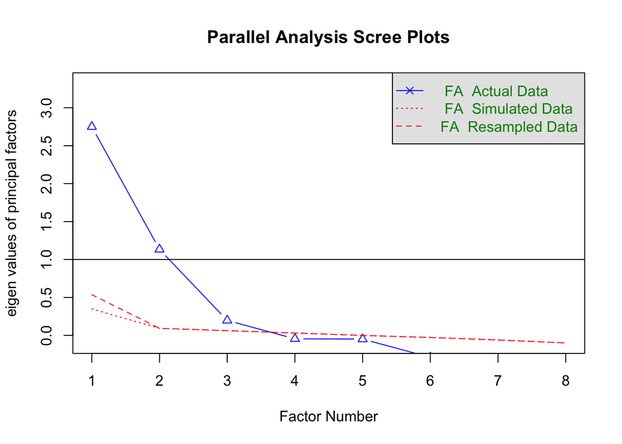

```
## Parallel analysis suggests that the number of factors =  3  and the number of components =  NA
```

```
## Factor Analysis using method =  minres
## Call: fa(r = behattitude, nfactors = 3, rotate = "Varimax", fm = "minres")
## Standardized loadings (pattern matrix) based upon correlation matrix
##                                   MR1  MR2  MR3   h2   u2 com
## sr_32_contact_useful             0.01 0.89 0.07 0.80 0.20 1.0
## sr_33_contact_pleasant           0.04 0.67 0.10 0.47 0.53 1.1
## sr_34_contact_cool_reversed      0.45 0.10 0.57 0.53 0.47 2.0
## sr_35_contact_easy_reversed      0.38 0.11 0.63 0.56 0.44 1.7
## sr_36_contact_exciting_reversed  0.34 0.23 0.62 0.55 0.45 1.9
## sr_37_contact_sensible           0.07 0.68 0.16 0.49 0.51 1.1
## sr_38_contact_admirable_reversed 0.84 0.02 0.22 0.75 0.25 1.1
## sr_39_contact_good_reversed      0.86 0.02 0.19 0.78 0.22 1.1
##
##                        MR1  MR2  MR3
## SS loadings           1.91 1.79 1.23
## Proportion Var        0.24 0.22 0.15
## Cumulative Var        0.24 0.46 0.62
## Proportion Explained  0.39 0.36 0.25
## Cumulative Proportion 0.39 0.75 1.00
##
## Mean item complexity =  1.4
## Test of the hypothesis that 3 factors are sufficient.
##
## The degrees of freedom for the null model are  28  and the objective function was  3.26 with Chi Square of  3409.72
## The degrees of freedom for the model are 7  and the objective function was  0.05
##
## The root mean square of the residuals (RMSR) is  0.02
## The df corrected root mean square of the residuals is  0.04
##
## The harmonic number of observations is  1027 with the empirical chi square  19.41  with prob <  0.007
## The total number of observations was  1050  with Likelihood Chi Square =  48.13  with prob <  3.4e-08
##
## Tucker Lewis Index of factoring reliability =  0.951
## RMSEA index =  0.075  and the 90 % confidence intervals are  0.056 0.095
## BIC =  -0.57
## Fit based upon off diagonal values = 1
## Measures of factor score adequacy
##                                                    MR1  MR2  MR3
## Correlation of (regression) scores with factors   0.91 0.92 0.78
## Multiple R square of scores with factors          0.82 0.85 0.61
## Minimum correlation of possible factor scores     0.65 0.70 0.22
```

```
##
## Loadings:
##                                  MR1   MR2   MR3
## sr_32_contact_useful                   0.894
## sr_33_contact_pleasant                 0.674
## sr_34_contact_cool_reversed      0.453       0.565
## sr_35_contact_easy_reversed      0.384       0.630
## sr_36_contact_exciting_reversed  0.336       0.621
## sr_37_contact_sensible                 0.681
## sr_38_contact_admirable_reversed 0.835
## sr_39_contact_good_reversed      0.859
##
##                  MR1   MR2   MR3
## SS loadings    1.907 1.794 1.230
## Proportion Var 0.238 0.224 0.154
## Cumulative Var 0.238 0.463 0.616
```

#### TPB Behavioral Attitude - 1st factor - Correlation

```
##
##  Spearman's rank correlation rho
##
## data:  d_accept$sr_38_contact_admirable_reversed and d_accept$sr_39_contact_good_reversed
## S = 45912935, p-value < 2.2e-16
## alternative hypothesis: true rho is not equal to 0
## sample estimates:
##       rho
## 0.7411731
```

#### TPB Behavioral Attitude - 2nd factor - Cronbach Alpha

```
##
## Reliability analysis
## Call: psych::alpha(x = d_pca_behavioralattitude2, use = "pairwise")
##
##   raw_alpha std.alpha G6(smc) average_r S/N   ase mean  sd median_r
##        0.8       0.8    0.73      0.57 3.9 0.011  2.6 1.4     0.61
##
##  lower alpha upper     95% confidence boundaries
## 0.78 0.8 0.82
##
##  Reliability if an item is dropped:
##                        raw_alpha std.alpha G6(smc) average_r S/N alpha se var.r
## sr_32_contact_useful        0.65      0.65    0.48      0.48 1.9    0.022    NA
## sr_33_contact_pleasant      0.76      0.76    0.61      0.61 3.1    0.015    NA
## sr_37_contact_sensible      0.76      0.76    0.61      0.61 3.2    0.015    NA
##                        med.r
## sr_32_contact_useful    0.48
## sr_33_contact_pleasant  0.61
## sr_37_contact_sensible  0.61
##
##  Item statistics
##                           n raw.r std.r r.cor r.drop mean  sd
## sr_32_contact_useful   1043  0.88  0.88  0.80   0.71  2.3 1.7
## sr_33_contact_pleasant 1043  0.82  0.83  0.69   0.61  2.6 1.6
## sr_37_contact_sensible 1036  0.83  0.83  0.68   0.61  3.0 1.7
##
## Non missing response frequency for each item
##                           0    1    2    3    4    5    6 miss
## sr_32_contact_useful   0.20 0.21 0.11 0.24 0.12 0.07 0.05 0.01
## sr_33_contact_pleasant 0.13 0.16 0.11 0.34 0.14 0.08 0.04 0.01
## sr_37_contact_sensible 0.12 0.11 0.11 0.28 0.19 0.12 0.07 0.01
```

.80 alpha shows good reliability, and it decreases when any items are dropped.

#### TPB Behavioral Attitude - 3rd factor - Cronbach Alpha

```
##
## Reliability analysis
## Call: psych::alpha(x = d_pca_behavioralattitude3, use = "pairwise")
##
##   raw_alpha std.alpha G6(smc) average_r S/N   ase mean  sd median_r
##       0.77      0.78     0.7      0.54 3.5 0.012  3.3 1.5     0.54
##
##  lower alpha upper     95% confidence boundaries
## 0.75 0.77 0.8
##
##  Reliability if an item is dropped:
##                                 raw_alpha std.alpha G6(smc) average_r S/N
## sr_34_contact_cool_reversed          0.70      0.71    0.55      0.55 2.4
## sr_35_contact_easy_reversed          0.68      0.68    0.52      0.52 2.2
## sr_36_contact_exciting_reversed      0.70      0.70    0.54      0.54 2.3
##                                 alpha se var.r med.r
## sr_34_contact_cool_reversed        0.018    NA  0.55
## sr_35_contact_easy_reversed        0.020    NA  0.52
## sr_36_contact_exciting_reversed    0.018    NA  0.54
##
##  Item statistics
##                                    n raw.r std.r r.cor r.drop mean  sd
## sr_34_contact_cool_reversed     1036  0.83  0.83  0.68   0.60  3.5 1.8
## sr_35_contact_easy_reversed     1036  0.85  0.84  0.71   0.62  3.3 1.9
## sr_36_contact_exciting_reversed 1033  0.82  0.83  0.69   0.61  3.3 1.6
##
## Non missing response frequency for each item
##                                    0    1    2    3    4    5    6 miss
## sr_34_contact_cool_reversed     0.09 0.10 0.09 0.11 0.33 0.13 0.15 0.01
## sr_35_contact_easy_reversed     0.10 0.11 0.13 0.15 0.25 0.11 0.15 0.01
## sr_36_contact_exciting_reversed 0.05 0.14 0.13 0.18 0.30 0.10 0.10 0.02
```

.77 alpha shows good reliability, and it decreases when any items are dropped.

$$\\[.05in]$$
### Perceived Behavioral Control - correlation
*“Imagine the idea of calling an elected official on a regular basis over the next year.”*
*“30 - How easy would it be for you to make these calls on a regular basis?”*
*“31 - How able might you be to make such calls on a regular basis?”*

```
##
##  Spearman's rank correlation rho
##
## data:  d_accept$sr_30_easy_to_call and d_accept$sr_31_able_to_call
## S = 68811266, p-value < 2.2e-16
## alternative hypothesis: true rho is not equal to 0
## sample estimates:
##       rho
## 0.6392419
```

The two measures of perceived behavioral control show a moderate-to-poor positive relationship, just barely under the .65 rule of thumb. Spearman’s rho is 0.6392419 with a p-value of 3.13843610^{-121}. This is not a strong enough correlation to justify a composite variable of the two items, so they will stay separate.

$$\\[.05in]$$

### Worldviews

We decided these will be kept as-is.

```
##  sr_41a_right_to_modify sr_41b_laws_of_nature sr_41c_ingenuity sr_41d_impotent
##  Min.   :1.000          Min.   :1.000         Min.   :1.000    Min.   :1.000
##  1st Qu.:2.000          1st Qu.:3.000         1st Qu.:3.000    1st Qu.:2.000
##  Median :3.000          Median :4.000         Median :3.000    Median :3.000
##  Mean   :2.841          Mean   :3.884         Mean   :3.136    Mean   :2.833
##  3rd Qu.:4.000          3rd Qu.:5.000         3rd Qu.:4.000    3rd Qu.:4.000
##  Max.   :5.000          Max.   :5.000         Max.   :5.000    Max.   :5.000
##  NA's   :3              NA's   :5             NA's   :5        NA's   :2
##  sr_41e_govt_do_more sr_41f_equity
##  Min.   :1.000       Min.   :1.000
##  1st Qu.:3.000       1st Qu.:3.000
##  Median :4.000       Median :3.000
##  Mean   :3.511       Mean   :3.374
##  3rd Qu.:4.000       3rd Qu.:4.000
##  Max.   :5.000       Max.   :5.000
##  NA's   :6           NA's   :3
```

```
## sr_41a_right_to_modify  sr_41b_laws_of_nature       sr_41c_ingenuity
##              1.1518050              0.9693529              1.0616550
##        sr_41d_impotent    sr_41e_govt_do_more          sr_41f_equity
##              1.0916798              1.1810602              1.1721897
```

$$\\[.05in]$$

## EDA - Categorical variables factoring & levels reduction

#### EDA - Race

```
##
## race_white race_other
##        633        176
```

```
##
##             race_white race_other
##   nocontact 0.82324841 0.80459770
##   once      0.12101911 0.09195402
##   moreonce  0.05573248 0.10344828
```

Race variable reduced to two levels: “white” and “other”. The question was a check-all-that-apply; if a respondent chose white along with any other races they were coded as white.

1. Number of responses: 633 white respondents and 176 other respondents.
2. Proportion of responses broken out by race

#### EDA - Q7 CC Belief

```
##
##   notchanging  most_natural natural_human    most_human    excl_human
##            69           154           374           238           207
```

Number of responses by answer option. Leaving these categories as-is.

#### EDA - Gender

```
##
## female   male
##    517    497
```

```
##
##                 female       male
##   nocontact 0.85408560 0.79107505
##   once      0.10311284 0.14198783
##   moreonce  0.04280156 0.06693712
```

Total females and males, and response proportions by gender.

#### EDA - Marital Status

Original levels:  
1=“single” 2=“married / partner” 3=“divorced / separated” 4=“widowed”

```
##
##   1   2   3   4
## 297 629  84  36
```

Collapsing down to three levels, though “Divorce/widow” might not have enough responses to support our analysis; need to double-check.

```
##
##          single married_partner   divorce_widow
##             297             629             120
```

```
##
##                 single married_partner divorce_widow
##   nocontact 0.82828283      0.80898876    0.86554622
##   once      0.11784512      0.13322632    0.08403361
##   moreonce  0.05387205      0.05778491    0.05042017
```

#### EDA - Children / no children

```
##
##   children nochildren
##        602        110
```

```
##
##               children nochildren
##   nocontact 0.84873950 0.84545455
##   once      0.10252101 0.08181818
##   moreonce  0.04873950 0.07272727
```

Total number of respondents by “children” and “no children” categories, as well as response proportions.

#### EDA - Education

Original levels:  
“1”=“some high_school”, “2”=“high_school grad”, “3”=“somecollege”, “4”=“Assoc degree”, “5”=“bachelordeg”, “6”=“graduatedeg”) Need to combine all Assoc deg or lower options so we have enough responses to analyze.

```
##
##   1   2   3   4   5   6
##  17  86 151  72 288 238
```

```
##
##                      1          2          3          4          5          6
##   nocontact 0.50000000 0.71428571 0.81333333 0.83333333 0.85314685 0.84388186
##   once      0.37500000 0.15476190 0.10666667 0.09722222 0.09790210 0.11392405
##   moreonce  0.12500000 0.13095238 0.08000000 0.06944444 0.04895105 0.04219409
```

Reduced levels:

```
##
## assocdeg_orlower      bachelordeg      graduatedeg
##              326              288              238
```

```
##
##             assocdeg_orlower bachelordeg graduatedeg
##   nocontact       0.77639752  0.85314685  0.84388186
##   once            0.13043478  0.09790210  0.11392405
##   moreonce        0.09316770  0.04895105  0.04219409
```

#### EDA - Employment Status

Original categories:  
“1”=“workfulltime”, “2”=“workparttime”, “3”=“homemaker”, “4”=“retired”, “5”=“student”, “6”=“unemployed”, “0”=“other”)

```
##
##   0   1   2   3   4   5   6
##  14 455  61  66 194  10  43
```

```
##
##                      0          1          2          3          4          5
##   nocontact 0.92857143 0.83148559 0.90163934 0.80303030 0.78645833 0.77777778
##   once      0.07142857 0.11529933 0.06557377 0.10606061 0.12500000 0.11111111
##   moreonce  0.00000000 0.05321508 0.03278689 0.09090909 0.08854167 0.11111111
##
##                      6
##   nocontact 0.76744186
##   once      0.13953488
##   moreonce  0.09302326
```

Reduced levels:  
Collapsed all other levels into “other” besides “full time work” and “retired” in order to have enough responses to analyze.

```
##
## workfull    other  retired
##      455      194      194
```

```
##
##               workfull      other    retired
##   nocontact 0.83148559 0.83419689 0.78645833
##   once      0.11529933 0.09844560 0.12500000
##   moreonce  0.05321508 0.06735751 0.08854167
```

#### EDA - Income

Original categories:  
“1”=“under25k”, “2”=“25-49k”, “3”=“50-74k”, “4”=“75-99k”, “5”=“100_150k”, “6”=“150-199k”, “7”=“200-249k”, “8”=“over250k”, 9=prefer not to answer

```
##
##   1   2   3   4   5   6   7   8   9
##  65 107 123 146 196  67  29  48  64
```

```
##
##                      1          2          3          4          5          6
##   nocontact 0.74603175 0.79245283 0.79674797 0.86301370 0.82989691 0.83582090
##   once      0.12698413 0.15094340 0.11382114 0.08904110 0.14948454 0.07462687
##   moreonce  0.12698413 0.05660377 0.08943089 0.04794521 0.02061856 0.08955224
##
##                      7          8          9
##   nocontact 0.93103448 0.80851064 0.79365079
##   once      0.03448276 0.08510638 0.11111111
##   moreonce  0.03448276 0.10638298 0.09523810
```

```
##
## under100k  100_150k  over150k
##       441       196       208
```

```
##
##              under100k   100_150k   over150k
##   nocontact 0.81050228 0.82989691 0.83009709
##   once      0.11643836 0.14948454 0.08252427
##   moreonce  0.07305936 0.02061856 0.08737864
```

#### EDA - Religion

Reduced levels to religious & non-religious

```
##
##    religious notreligious
##          595          232
```

```
##
##              religious notreligious
##   nocontact 0.82881356   0.78695652
##   once      0.11525424   0.12173913
##   moreonce  0.05593220   0.09130435
```

#### EDA - Political Affiliation

Original levels:  
“1”=“democrat”, “2”=“republican”, “3”=“independent”, “4”=“green party”, “5”=“libertarian”, “6”=“no party”, “0”=“other”)

```
##
##   0   1   2   3   4   5   6
##   5 273 239 239  16  11  58
```

```
##
##                      0          1          2          3          4          5
##   nocontact 1.00000000 0.79704797 0.84033613 0.83966245 0.87500000 0.81818182
##   once      0.00000000 0.12546125 0.11344538 0.10548523 0.00000000 0.18181818
##   moreonce  0.00000000 0.07749077 0.04621849 0.05485232 0.12500000 0.00000000
##
##                      6
##   nocontact 0.73214286
##   once      0.16071429
##   moreonce  0.10714286
```

Reduced levels:

```
##
##    democrat  republican independent       other
##         273         239         239          90
```

```
##
##               democrat republican independent      other
##   nocontact 0.79704797 0.84033613  0.83966245 0.78409091
##   once      0.12546125 0.11344538  0.10548523 0.12500000
##   moreonce  0.07749077 0.04621849  0.05485232 0.09090909
```

#### EDA - Political Ideology

Original levels:  
“1”=“very liberal”, “2”=“somewhat liberal”, “3”=“moderate”, “4”=“somewhat conservative”, “5”=“very conservative”)

```
##
##   1   2   3   4   5
## 118 140 337 135 112
```

```
##
##                      1          2          3          4          5
##   nocontact 0.80508475 0.82014388 0.83132530 0.83703704 0.78378378
##   once      0.10169492 0.09352518 0.11144578 0.11851852 0.16216216
##   moreonce  0.09322034 0.08633094 0.05722892 0.04444444 0.05405405
```

Reduced levels:

```
##
##      liberal     moderate conservative
##          258          337          247
```

```
##
##                liberal   moderate conservative
##   nocontact 0.81322957 0.83132530   0.81300813
##   once      0.09727626 0.11144578   0.13821138
##   moreonce  0.08949416 0.05722892   0.04878049
```

Collapsing the two liberal levels and two conservative levels into one level apiece.

## Listwise Deletion

```
## [1] 510
```

```
## [1] 36
```

The response variable for this analysis is #12a: “In the last twelve months, how many times have you taken the following actions related to climate change?  
Answer option: Contacted elected officials via mail, email, or phone to urge them to take action to reduce climate change.”

All explanatory variables were treated as continuous, except for the following categorical vars which were reduced to the following smaller number of factor levels in order to have enough responses per level for analysis.

- #7: What do you believe about climate change?: Left as-is
- Race: Reduced to “white” and “other”
- Gender: Reduced to “male” and “female”
- Children: Reduced to “children” (any age) and “no children”
- Marital status: Reduced to “single” “married/partner” and “divorce/widow”
- Education: Reduced to “associate’s degree or lower”, “bachelor’s degree” and “graduate/professional degree”
- Employment status: Reduced to “work full-time” “retired” and “other”
- Income: Reduced to “under 100k”, “100-150k” and “over 150k”
- Religion: Reduced to “religious” and “not religious”
- Political party affiliation: Reduced to “democrat” “republican” “independent” and “other”
- Political ideology: Reduced to “liberal” “moderate” and “conservative”

# Ordinal logistic regression model. Model selection using AIC w/ backwards selection

```
## Call:
## polr(formula = OLR_complete_cases$sr_12a_actions_contacted_officials ~
##     age_true + race_white_dumvar + gender_dumvar + children_dumvar +
##         sr_75_religion_dumvar + sr_56_marital_status + sr_61_education +
##         sr_71_employment_status + sr_72_income + sr_78_political_affiliation +
##         sr_79_political_leaning + sr_7_believe_about_climate_change +
##         descdynamicnorms_comp + desccontactnorms_all_comp + descrolemodelnorms_all_comp +
##         injunctcontactnorms_all_comp + injunctmotivation_all_comp +
##         cimbenefits_comp + cimperceivedrisk_comp + sr_10_harm_you_personally_reversed +
##         sr_11_harm_future_generations_reversed + sr_21a_effective_actions_contacting_officials +
##         efficacy_effectiveness_all_comp + efficacy_competresp_all_comp +
##         behatt_admirablegood_comp + behatt_usefulpleasantsensible_comp +
##         behatt_coolexcitingeasy_comp + sr_30_easy_to_call + sr_31_able_to_call +
##         sr_41a_right_to_modify + sr_41b_laws_of_nature + sr_41c_ingenuity +
##         sr_41d_impotent + sr_41e_govt_do_more + sr_41f_equity,
##     data = OLR_complete_cases, Hess = T)
##
## Coefficients:
##                                                   Value Std. Error  t value
## age_true                                       -0.02099    0.01361 -1.54241
## race_white_dumvarrace_other                     0.14028    0.44585  0.31464
## gender_dumvarmale                              -0.15217    0.33189 -0.45849
## children_dumvarnochildren                       0.72208    0.46461  1.55417
## sr_75_religion_dumvarnotreligious              -0.03502    0.36347 -0.09634
## sr_56_marital_statusmarried_partner            -0.10715    0.41011 -0.26128
## sr_56_marital_statusdivorce_widow              -0.17961    0.59132 -0.30374
## sr_61_educationbachelordeg                     -0.25620    0.37482 -0.68354
## sr_61_educationgraduatedeg                     -0.57378    0.43298 -1.32520
## sr_71_employment_statusother                   -0.92932    0.46563 -1.99585
## sr_71_employment_statusretired                  0.34682    0.39654  0.87461
## sr_72_income100_150k                           -0.02601    0.41200 -0.06313
## sr_72_incomeover150k                           -0.13757    0.41890 -0.32841
## sr_78_political_affiliationrepublican          -0.05834    0.50577 -0.11535
## sr_78_political_affiliationindependent         -0.17702    0.43698 -0.40509
## sr_78_political_affiliationother                0.88764    0.64074  1.38534
## sr_79_political_leaningmoderate                -0.06293    0.43630 -0.14423
## sr_79_political_leaningconservative            -0.55108    0.52684 -1.04600
## sr_7_believe_about_climate_changemost_natural  -0.58537    0.77244 -0.75782
## sr_7_believe_about_climate_changenatural_human -0.25292    0.71270 -0.35487
## sr_7_believe_about_climate_changemost_human    -0.32452    0.72689 -0.44645
```

[output cut: 17 more lines]

```
## sr_31_able_to_call                              0.10929    0.15055  0.72593
## sr_41a_right_to_modify                         -0.18437    0.16525 -1.11568
## sr_41b_laws_of_nature                          -0.09079    0.22557 -0.40250
## sr_41c_ingenuity                               -0.31924    0.18433 -1.73189
## sr_41d_impotent                                 0.13068    0.17042  0.76682
## sr_41e_govt_do_more                             0.07645    0.19527  0.39152
## sr_41f_equity                                  -0.01677    0.20481 -0.08186
##
## Intercepts:
##                Value   Std. Error t value
## nocontact|once  2.4313  1.8667     1.3025
## once|moreonce   4.0981  1.8717     2.1895
##
## Residual Deviance: 377.3989
## AIC: 471.3989
```

```
## Start:  AIC=471.4
## OLR_complete_cases$sr_12a_actions_contacted_officials ~ age_true +
##     race_white_dumvar + gender_dumvar + children_dumvar + sr_75_religion_dumvar +
##     sr_56_marital_status + sr_61_education + sr_71_employment_status +
##     sr_72_income + sr_78_political_affiliation + sr_79_political_leaning +
##     sr_7_believe_about_climate_change + descdynamicnorms_comp +
##     desccontactnorms_all_comp + descrolemodelnorms_all_comp +
##     injunctcontactnorms_all_comp + injunctmotivation_all_comp +
##     cimbenefits_comp + cimperceivedrisk_comp + sr_10_harm_you_personally_reversed +
##     sr_11_harm_future_generations_reversed + sr_21a_effective_actions_contacting_officials +
##     efficacy_effectiveness_all_comp + efficacy_competresp_all_comp +
##     behatt_admirablegood_comp + behatt_usefulpleasantsensible_comp +
##     behatt_coolexcitingeasy_comp + sr_30_easy_to_call + sr_31_able_to_call +
##     sr_41a_right_to_modify + sr_41b_laws_of_nature + sr_41c_ingenuity +
##     sr_41d_impotent + sr_41e_govt_do_more + sr_41f_equity
##
##                                                 Df    AIC
## - sr_7_believe_about_climate_change              4 464.75
## - sr_56_marital_status                           2 467.51
## - sr_72_income                                   2 467.51
## - sr_78_political_affiliation                    3 468.31
## - sr_79_political_leaning                        2 468.83
## - sr_61_education                                2 469.19
## - sr_41f_equity                                  1 469.41
## - injunctmotivation_all_comp                     1 469.41
## - sr_75_religion_dumvar                          1 469.41
## - sr_21a_effective_actions_contacting_officials  1 469.41
## - sr_30_easy_to_call                             1 469.45
## - behatt_coolexcitingeasy_comp                   1 469.48
## - race_white_dumvar                              1 469.50
## - sr_41e_govt_do_more                            1 469.55
## - sr_41b_laws_of_nature                          1 469.56
## - gender_dumvar                                  1 469.61
## - descdynamicnorms_comp                          1 469.84
## - sr_31_able_to_call                             1 469.92
## - behatt_admirablegood_comp                      1 469.94
## - sr_41d_impotent                                1 469.99
## - behatt_usefulpleasantsensible_comp             1 470.17
## - efficacy_effectiveness_all_comp                1 470.29
## - descrolemodelnorms_all_comp                    1 470.54
```

[output cut: 925 more lines]

```
##     injunctcontactnorms_all_comp + cimbenefits_comp + cimperceivedrisk_comp +
##     sr_10_harm_you_personally_reversed + sr_11_harm_future_generations_reversed +
##     sr_41c_ingenuity
##
##                                          Df    AIC
## <none>                                      421.49
## - descrolemodelnorms_all_comp             1 421.52
## - sr_10_harm_you_personally_reversed      1 421.98
## - age_true                                1 422.12
## - injunctcontactnorms_all_comp            1 423.39
## - sr_11_harm_future_generations_reversed  1 423.53
## - sr_41c_ingenuity                        1 425.29
## - cimperceivedrisk_comp                   1 425.97
## - desccontactnorms_all_comp               1 430.77
## - cimbenefits_comp                        1 432.60
```

$$\\[.05in]$$
#### Break out final model for readability

```
## Call:
## polr(formula = OLR_complete_cases$sr_12a_actions_contacted_officials ~
##     age_true + desccontactnorms_all_comp + descrolemodelnorms_all_comp +
##         injunctcontactnorms_all_comp + cimbenefits_comp + cimperceivedrisk_comp +
##         sr_10_harm_you_personally_reversed + sr_11_harm_future_generations_reversed +
##         sr_41c_ingenuity, data = OLR_complete_cases, Hess = T)
##
## Coefficients:
##                               age_true              desccontactnorms_all_comp
##                            -0.01808652                             0.77405908
##            descrolemodelnorms_all_comp           injunctcontactnorms_all_comp
##                            -0.21820779                             0.47182410
##                       cimbenefits_comp                  cimperceivedrisk_comp
##                             0.57561243                             0.54000978
##     sr_10_harm_you_personally_reversed sr_11_harm_future_generations_reversed
##                             0.32063427                            -0.48779640
##                       sr_41c_ingenuity
##                            -0.35015441
##
## Intercepts:
## nocontact|once  once|moreonce
##       4.334952       5.916856
##
## Residual Deviance: 399.4913
## AIC: 421.4913
```

$$\\[.05in]$$
#### Interpreting final model coefficients and intercepts

#### Interpreting proportional odds ratios and CIs

```
##                                            OR  2.5 % 97.5 %
## age_true                               0.9821 0.9606 1.0038
## desccontactnorms_all_comp              2.1686 1.3749 3.4903
## descrolemodelnorms_all_comp            0.8040 0.5919 1.0856
## injunctcontactnorms_all_comp           1.6029 1.0037 2.5592
## cimbenefits_comp                       1.7782 1.2994 2.4601
## cimperceivedrisk_comp                  1.7160 1.1256 2.7352
## sr_10_harm_you_personally_reversed     1.3780 0.9241 2.0409
## sr_11_harm_future_generations_reversed 0.6140 0.3712 0.9885
## sr_41c_ingenuity                       0.7045 0.5260 0.9373
```

*Non-significant predictors:* Age Descriptive norms related to role models Belief on whether CC will harm you personally (sr_10 harm you personally)

*Significant predictors, coefficients, and proportional odds ratios, in descending order of leverage:* Descriptive Contact Norms: 0.77 For a one unit increase in the composite variable of descriptive contact norms, the odds of moving from “no contact” to “one contact” or “more than one contact” (in the last twelve months) are 2.17 times greater, given that the other variables in the model are held constant.

CIM Benefits (interpersonal discussion / hearing about CC): 0.58 For a one unit increase in composite variable of CIM Benefits, the odds of moving from “no contact” to “one contact” or “more than one contact” (in the last twelve months) are 1.78 times greater, given that the other variables in the model are held constant.

*Discussion* Descriptive Contact Norms, CIM Benefits, Perceived Risk, Injunctive Contact Norms all have a positive effect on propensity to contact officials. The more a person perceives positive descriptive norms related to contacting officials; perceives positive injunctive norms related to contacting officials; hears about CC from friends, media, & public figures; or perceives CC as a risk, the more likely they are to contact officials. It’s interesting that hearing about CC more often (through interpersonal discussion, mass media, or from public figures) is predictive of contacting officials along with the other more intuitive factors.

Conversely, the more a person believes CC will harm future generations or the more they agree with the statement that “human ingenuity will ensure we do not make the Earth unlivable”, the less likely they are to contact officials. The first could be explained by the person believing that CC is more an issue for the distant future; if CC will only harm future generations, why bother contacting officials now? Additionally, the ecological worldview that human ingenuity will solve CC may align with a person thinking CC is more a technological problem than a social one, and this worldview may align with the person perceiving less risk from CC since they see CC as a problem that will inevitably be solved by human innovation.

$$\\[.05in]$$
## Checking OLR assumptions #### Multi-collinearity

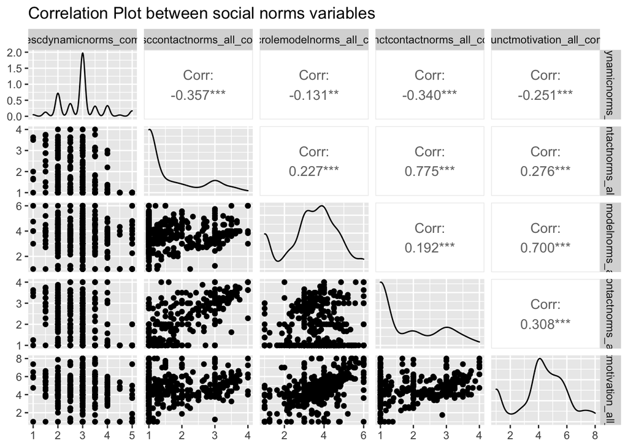

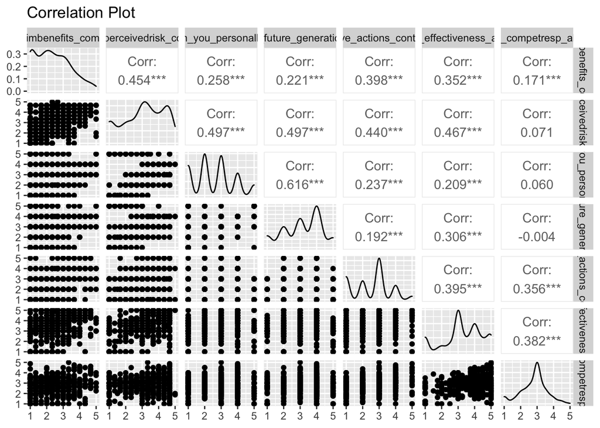

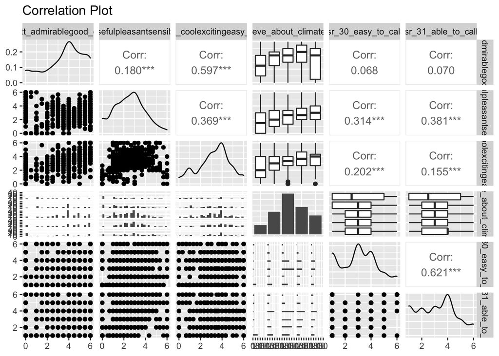

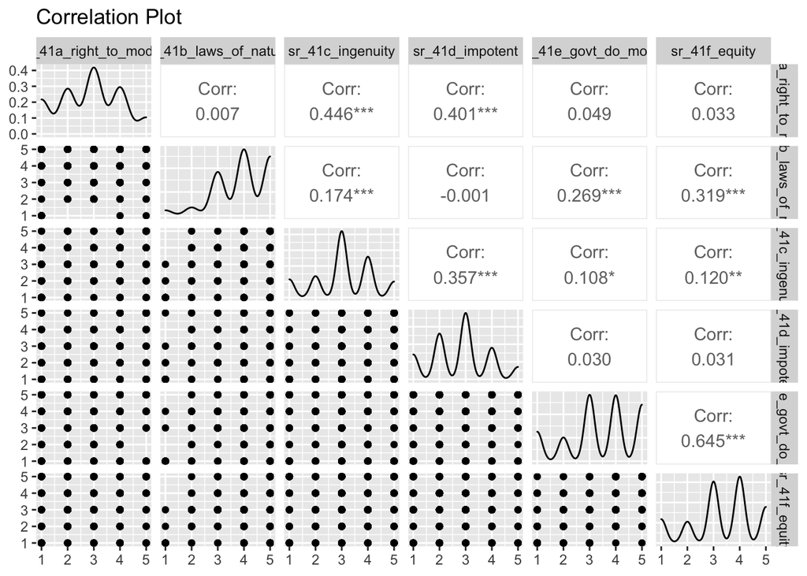

```
##                               age_true              desccontactnorms_all_comp
##                               19.13080                               17.02567
##            descrolemodelnorms_all_comp           injunctcontactnorms_all_comp
##                               20.87935                               13.90142
##                       cimbenefits_comp                  cimperceivedrisk_comp
##                               38.34854                               20.94107
##     sr_10_harm_you_personally_reversed sr_11_harm_future_generations_reversed
##                               36.15646                               11.99810
##                       sr_41c_ingenuity
##                               59.03590
```

#### Parallel regression assumption via Brant’s test

```
## ----------------------------------------------------------------------------
## Test for                 X2  df  probability
## ----------------------------------------------------------------------------
## Omnibus                      27.03   9   0
## age_true                 2.52    1   0.11
## desccontactnorms_all_comp            5.42    1   0.02
## descrolemodelnorms_all_comp          0.37    1   0.54
## injunctcontactnorms_all_comp         0.04    1   0.85
## cimbenefits_comp             0.12    1   0.73
## cimperceivedrisk_comp                0.07    1   0.79
## sr_10_harm_you_personally_reversed       0.02    1   0.88
## sr_11_harm_future_generations_reversed   0.05    1   0.82
## sr_41c_ingenuity             0   1   0.95
## ----------------------------------------------------------------------------
##
## H0: Parallel Regression Assumption holds
```